# Formulating a Research Question

GE2021 Research Technology, Fall 2026

Chad (Chungil Chae)

cchae@kean.edu

Tue, 15 September 2026

# Learning Objectives

1. Choose a research topic.
2. Explain how to operationalize research constructs
3. Describe the different types of variables
4. Formulate the various types of hypotheses
5. Create a visualization of a research question (Pajo, 2022)

## SHORT VIDEO INTRODUCTION

[video not shown]

# Selecting Your Research Topic

## Topic Choice

What is the anatomy of a topic? (Colquitt & George, 2011)

1. **Significance**: Taking on “Grand Challenges”
2. **Novelty**: Changing the Conversation
3. **Curiosity**: Catching and Holding Attention
4. **Scope**: Casting a Wider Net
5. **Actionability**: Insights for Practice

## Fundamental vs Applied Research

- **Fundamental research**: looks at the world at large and tries to generate new ideas or explanation about how the world works and why; may not have application in everyday life in the immediate sense.
- **Applied research**: seeks to solve a specific societal problem or uncover more information about a particular issue; has direct implications in practice.

## Narrowing the Research Topic

- Two features of a broader topic can lead to the research question: the constructs and the population of interest.
  - **Construct**: a concept that is possible to measure in a form.
  - **The population of interest**: group of subject that share simialr charateristics or tied in a similar context that researcher have interested in

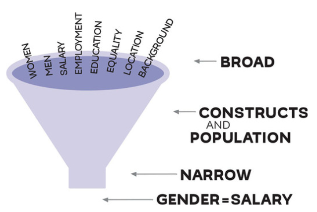

# Operationalization of Constructions

> Operationalization is nothing more than our ability to transform constructs into measurement pieces. The best researcher is able to measrue all the characteristics of a construct.
- **Operationalization**: turning constructs into actual variables to measure
- **Variable**: a specific feature or aspect of the construct that can take different values for each participant in a study.
- **Conceptualization**: the process of breaking down constructs into smaller pieces and clarifying to know the precise meaning of each.

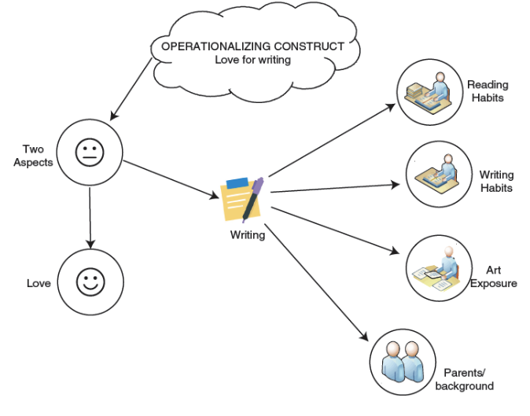

# Types of Variables: Collecting Information

## Independent and Dependent Variables

- **Independent variable**: the explanatory or predicting variable that explains the variation in the dependent variable; often constant/doesn’t change for the participant
- **Dependent variable**: the outcome; what researchers want to find out from a study and what they hope is influenced by the independent variable.
- Variables are unique to each study; a variable can be dependent in one study and independent in another.

## Control Variables

- **Control variables**: any variables that are used to control the results; not directly related to the focus of the study but crucial for understanding the relationship between the variables of focus.
- They help minimize biases and provide more accurate findings.

## Confounding and Disturbance Variables

- **Confounding variables**: influence the independent variable in such a way that the results from the dependent variable become untrustworthy; could not have been controlled or predicted during the study’s design; only become apparent during data collection or analysis.
- **Disturbance variable**: lurks in the background and disturbs the findings of the dependent variable; common characteristics of participants mislead the findings of the study without the researchers’ awareness.

## Moderators and Mediators

- **Moderators**: variables that can strengthen or weaken an already established relationship between the independent and dependent variables.
- **Mediators**: intervening variables that interfere with the relationship between the main variables; when a mediator is present, the relationship between the independent and dependent variables may not even exist anymore.

# Types of Hypotheses

- **Hypothesis**: a statement that predicts a specific phenomenon or behavior.
- They are usually present in a quantitative study but not a qualitative one.

## Alternative Hypothesis and Null Hypothesis

- **Alternative hypothesis**: the prediction based on literature and theory about what the testing results will be; that is, what the variables are expected to look like once the data is collected.
- **Null hypothesis**: claims there is no relationship between the variables of interest in the study; this is the hypothesis researchers are actually testing with their findings.
- **Research outcomes have two options**: reject the null hypothesis in favor of the alternative hypothesis, or fail to reject the null hypothesis.

## Directional Hypothesis and Nondirectional Hypothesis

- **Directional hypothesis**: predicts a specific course for the variables
- **Nondirectional hypothesis**: has no direction and simply predicts a relationship between two or more variables; rather than making assumptions on how the variables will behaving, researchers are investigating the possible relationship between variables.

## Open-Ended Question

- For qualitative studies rather than quantitative; that is, when the researcher has many constructs but is not attempting to measure them
- A qualitative study asks different types of research questions and has a different methodology to collect data.

# Visualizing a Research Question

## Diagram

- Try drawing the reserach question
- It can be helpful to make a drawing of the research question to help visualize it.

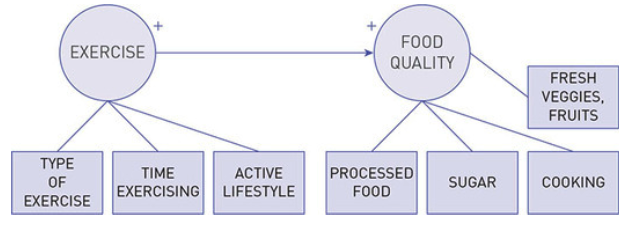